# Nuevo reporte de Conectividad Terrestre

Publicación del Informe de Conectividad Terrestre de la Argentina, con información turística del mercado de buses de media y larga distancia.

A partir de la colaboración con la [Comisión Nacional de Regulación del Transporte (CNRT), dependiente de la Secretaría de Transporte de la Nación](https://www.argentina.gob.ar/transporte/cnrt), la Dirección Nacional de Mercados y Estadística (DNMYE) pone a disposición un nuevo **[reporte mensual](https://tableros.yvera.tur.ar/conectividad_terrestre.html)** para el análisis del mercado del transporte automotor interurbano y el flujo de personas al interior el país.

Dicho informe proyecta de manera sintética **información actualizada de servicios regulares de jurisdicción nacional entre dos cabeceras de origen y destino interurbano realizados por micros de media y larga distancia de empresas de transporte automotor registradas** correspondientes al mes previo a la fecha de publicación. Los datos sobre los cuales se construye, pueden encontrarse de manera [abierta y desgregada](https://datos.yvera.gob.ar/dataset/conectividad-terrestre-interurbana) en el [portal de datos abiertos](https://datos.yvera.gob.ar/) del [Sistema de Información Turística de la Argentina (SINTA)](https://www.yvera.tur.ar/sinta/)

Este nuevo recurso se complementa con el [Tablero de Conectividad Terrestre Interurbana](https://tableros.yvera.tur.ar/conectividad_terrestre/), el cual reúne (de manera agregada y desagregada) información sobre **viajes, fechas, orígenes, destinos, asientos y pasajeros** de servicios regulares de jurisdicción nacional. En conjunto, ambos recursos facilitan el estudio de los ejes y rutas terrestres que resultan relevantes para el desarrollo de los destinos regionales y ciudades pequeñas y medianas del país.

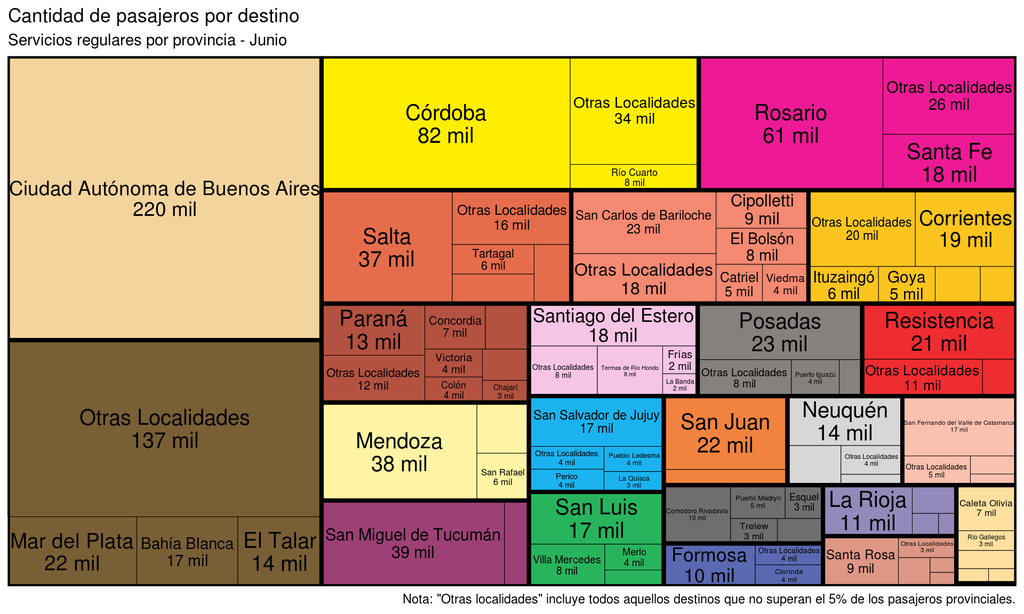

# Referencias

- **[Documento de Trabajo](https://tableros.yvera.tur.ar/recursos/biblioteca/conectividad_terrestre.pdf)**
- **[Tablero](https://tableros.yvera.tur.ar/conectividad_terrestre/)**
- **[Datos Abiertos](https://datos.yvera.gob.ar/dataset/conectividad-terrestre-interurbana)**
- **[CNRT](https://www.argentina.gob.ar/transporte/cnrt/estadisticas)**

Para recibir las novedades del SINTA escribíle al bot de Telegram de la DNMyE *SintIA*: @RDatinaBot 🤖